# Working with Landsat Data in the Amazon Web Services (AWS) Cloud

This tutorial demonstrates how users access Landsat Data stored within the AWS Cloud environment using basic commands. Landsat data stored in the AWS Cloud is located within U.S. West (Oregon) us-west-2 region in a requester pays Simple Storage Services (S3) bucket. Users interested in utilizing direct access to Landsat data stored in S3 are encouraged to visit the Requester Pays Documentation Page (https://docs.aws.amazon.com/AmazonS3/latest/dev/RequesterPaysBuckets.html) for information concerning potential egress costs to accessing Landsat data with this method.

**AWS Bucket Name:** usgs-landsat (Requester Pays)  
**AWS Region:** US West (Oregon) us-west-2

An AWS account is required before undertaking this tutorial. Please see the AWS Account website to establish an account (https://aws.amazon.com/account/).

# Use Case Example

This tutorial uses AWS Command Line Interface (CLI) to demonstrate how to list and download Landsat objects within an S3 Bucket. Users can find additional information regarding AWS CLI via the AWS CLI documentation website (https://aws.amazon.com/cli/). This tutorial also uses commonly available Python Tools to draw a preview of a Landsat scene by reading the Landsat Data directly from S3.

# Topics Covered

1. **Accessing Landsat Data without an AWS Account**  
   1.1 This section demonstrates the response that users should expect to receive when trying to access the usgs-landsat S3 Bucket with AWS CLI without an AWS Account.  
   1.2 This section demonstrates the response that users should expect to receive when trying to access the usgs-landsat S3 Bucket using Python tools without an AWS Account.
2. **Accessing Landsat Data with an AWS Account**  
   2.1 This section demonstrates the response users should expect to receive when trying to access the usgs-landsat S3 Bucket with AWS CLI with an AWS Account.  
   2.2 This section demonstrates the response users should expect to receive when trying to access the usgs-landsat S3 Bucket using Python tools with an AWS Account.

# 1. Accessing Landsat Data without an AWS Account

Important: The usgs-landsat S3 bucket is a Requester Pays Bucket where the requester (users) may incur costs for accessing the data. If a requester pays acknowledgement is not properly passed with the request the AWS CLI command or python call will return a denial of service error. This section provides an example of the errors returned when the user has not properly included the requester pays acknowledgement within the AWS CLI or python request.

## 1.1 AWS Command Line Response when users to not have an AWS Account

### This command will list the contents within the AWS Bucket

```python
! aws s3 ls s3://usgs-landsat/collection02/
```

[output not shown]

### This command will download an object in S3 to the user's local computer

```python
! aws s3api get-object --bucket usgs-landsat --key collection02/level-2/standard/oli-tirs/2020/026/027/LC08_L2SP_026027_20200827_20200906_02_T1/LC08_L2SP_026027_20200827_20200906_02_T1_MTL.txt LC08_L2SP_026027_20200827_20200906_02_T1_MTL.txt
```

[output not shown]

## 1.2 Python Response when users do not have an AWS Account

### Import Packages

```python
from matplotlib.pyplot import imshow
import rasterio as rio
%matplotlib inline
```

### Load Cloud Optimized GeoTIFF (COG) Band File from the S3 Bucket

```python
cog = 's3://usgs-landsat/collection02/level-2/standard/oli-tirs/2020/026/027/LC08_L2SP_026027_20200827_20200906_02_T1/LC08_L2SP_026027_20200827_20200906_02_T1_SR_B2.TIF'
```

### Read COG Band File from the S3 Bucket and Display It

```python
with rio.open(cog) as src:
    profile = src.profile
    arr = src.read(1)
imshow(arr)
```

[output not shown]

### Important: This will produce an error message because we have not properly authenticated to with AWS to agree to the terms of the requester pays bucket. Before running the next section clear the kernel before continuing.

# 2. Accessing Landsat Data with an AWS Account

Important: The usgs-landsat S3 bucket is a Requester Pays Bucket where the requester (user) may incur costs for accessing the data. This section demonstrates sample responses returned to the user’s computer when users have acknowledged requester pays (agreed to pay any incurred charges) for both AWS CLI commands and python requests.

## 2.1 AWS Command Line Response when the user has an AWS Account

### This command will list the contents within the AWS Bucket

```python
! aws s3 ls s3://usgs-landsat/collection02/level-2/standard/oli-tirs/2020/026/027/LC08_L2SP_026027_20200827_20200906_02_T1/ --request-payer requester
```

```
2020-09-23 22:24:56     117122 LC08_L2SP_026027_20200827_20200906_02_T1_ANG.txt
2020-09-23 22:25:00      14549 LC08_L2SP_026027_20200827_20200906_02_T1_MTL.json
2020-09-23 22:24:57      15424 LC08_L2SP_026027_20200827_20200906_02_T1_MTL.txt
2020-09-23 22:24:57      22726 LC08_L2SP_026027_20200827_20200906_02_T1_MTL.xml
2020-09-20 02:51:33    2670023 LC08_L2SP_026027_20200827_20200906_02_T1_QA_PIXEL.TIF
2020-09-20 02:51:33     230417 LC08_L2SP_026027_20200827_20200906_02_T1_QA_RADSAT.TIF
2020-09-20 02:51:33   74920387 LC08_L2SP_026027_20200827_20200906_02_T1_SR_B1.TIF
2020-09-20 02:51:34   72961917 LC08_L2SP_026027_20200827_20200906_02_T1_SR_B2.TIF
2020-09-20 02:51:34   74604511 LC08_L2SP_026027_20200827_20200906_02_T1_SR_B3.TIF
2020-09-20 02:51:35   73094885 LC08_L2SP_026027_20200827_20200906_02_T1_SR_B4.TIF
2020-09-20 02:51:36   82065367 LC08_L2SP_026027_20200827_20200906_02_T1_SR_B5.TIF
2020-09-20 02:51:36   77232505 LC08_L2SP_026027_20200827_20200906_02_T1_SR_B6.TIF
2020-09-20 02:51:37   73160584 LC08_L2SP_026027_20200827_20200906_02_T1_SR_B7.TIF
2020-09-20 02:51:37    3614439 LC08_L2SP_026027_20200827_20200906_02_T1_SR_QA_AEROSOL.TIF
2020-09-23 22:25:13      11265 LC08_L2SP_026027_20200827_20200906_02_T1_SR_stac.json
2020-09-20 02:51:38   23059897 LC08_L2SP_026027_20200827_20200906_02_T1_ST_ATRAN.TIF
2020-09-20 02:51:38   72849244 LC08_L2SP_026027_20200827_20200906_02_T1_ST_B10.TIF
2020-09-20 02:51:39   20444128 LC08_L2SP_026027_20200827_20200906_02_T1_ST_CDIST.TIF
2020-09-20 02:51:39   14257440 LC08_L2SP_026027_20200827_20200906_02_T1_ST_DRAD.TIF
2020-09-20 02:51:39   26285103 LC08_L2SP_026027_20200827_20200906_02_T1_ST_EMIS.TIF
2020-09-20 02:51:40   11855588 LC08_L2SP_026027_20200827_20200906_02_T1_ST_EMSD.TIF
2020-09-20 02:51:40   25311062 LC08_L2SP_026027_20200827_20200906_02_T1_ST_QA.TIF
2020-09-20 02:51:41   57800409 LC08_L2SP_026027_20200827_20200906_02_T1_ST_TRAD.TIF
2020-09-20 02:51:41   21904540 LC08_L2SP_026027_20200827_20200906_02_T1_ST_URAD.TIF
2020-09-23 22:25:13      10462 LC08_L2SP_026027_20200827_20200906_02_T1_ST_stac.json
2020-09-23 22:24:57      72973 LC08_L2SP_026027_20200827_20200906_02_T1_thumb_large.jpeg
2020-09-23 22:24:57       9992 LC08_L2SP_026027_20200827_20200906_02_T1_thumb_small.jpeg
```

### This commnad will download an object in S3 to the user's local computer

```python
! aws s3api get-object --bucket usgs-landsat --key collection02/level-2/standard/oli-tirs/2020/026/027/LC08_L2SP_026027_20200827_20200906_02_T1/LC08_L2SP_026027_20200827_20200906_02_T1_MTL.txt  --request-payer requester LC08_L2SP_026027_20200827_20200906_02_T1_MTL.txt
```

```
{
    "AcceptRanges": "bytes",
    "LastModified": "Wed, 23 Sep 2020 22:24:57 GMT",
    "ContentLength": 15424,
    "ETag": "\"cefa64a7e93a288f35b9d5bcadec30dc\"",
    "VersionId": "_w0A_JeRBgXkmKetbl2yhq12m9uN3Y9H",
    "ContentType": "text/plain",
    "Metadata": {},
    "RequestCharged": "requester",
    "TagCount": 3
}
```

## 2.2 Python Response when users have an AWS Account

### Import Packages

```python
import boto3
from matplotlib.pyplot import imshow
import rasterio as rio
from rasterio.session import AWSSession
```

### Setup AWS Requester Pays Environment

```python
aws_session = AWSSession(boto3.Session(), requester_pays=True)
```

### Load Cloud Optimized GeoTIFF (COG) Band File from the S3 Bucket

```python
cog = 's3://usgs-landsat/collection02/level-2/standard/oli-tirs/2020/026/027/LC08_L2SP_026027_20200827_20200906_02_T1/LC08_L2SP_026027_20200827_20200906_02_T1_SR_B2.TIF'
```

### Read COG Band File from the S3 Bucket and Display It

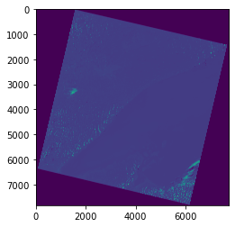

```python
with rio.Env(aws_session):
    with rio.open(cog) as src:
        profile = src.profile
        arr = src.read(1)

imshow(arr)
```

### Congratulations! You have now not only learned how to access the Landsat Data stored within the AWS S3 Cloud Storage and how to properly work with a requester pays bucket. You can incorporate this tutorial into your workflow. We anticipate releasing future tutorials on how users can benefit from using Landsat Data stored in AWS in their workflows

# Contact Information

### Material written by Nathan Roberts<sup>1</sup>

**Contact:** custserv@usgs.gov  
**Voice:** +1-605-594-6151  
**Date last modified:** 11-16-2020

<sup>1</sup>KBR Inc., contractor to the U.S. Geological Survey, Earth Resources Observation and Science (EROS) Center, Sioux Falls, South Dakota, 57198-001, USA. Work performed under USGS contract TSSC.